# Reproducible reporting in R

March 01, 2016

## Overview

- Reproducible reporting
- Working in Rstudio projects
- Introduction to Rmarkdown
- Bookdown extension

## OpenEarth data management

- Data, Models, Tools
- Generic workflow and conventions
  - Version control of data and tools
  - Traceable and reproducible
  - Use available open technical and semantic standards
  - Open Source software

## Reproducible data products

[figure not shown]

## Extend to documents

- Open source
- Reproducible
  - Jupyter notebooks offline/online
  - Rmarkdown reproducible reports
  - Rshiny interactive web applications

## Housekeeping

Open source IDE - Rstudio desktop and Rstudio server

Work in PROJECTS

## Rstudio templates

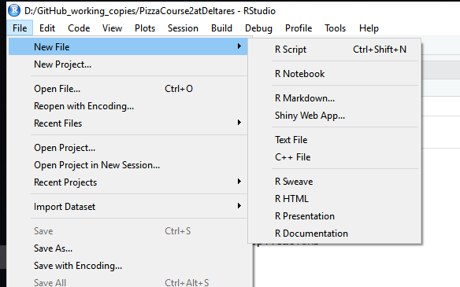

## Version control in Rstudio

[figure not shown]

## Help functions and cheatsheets

Help (F1)

Cheatsheets

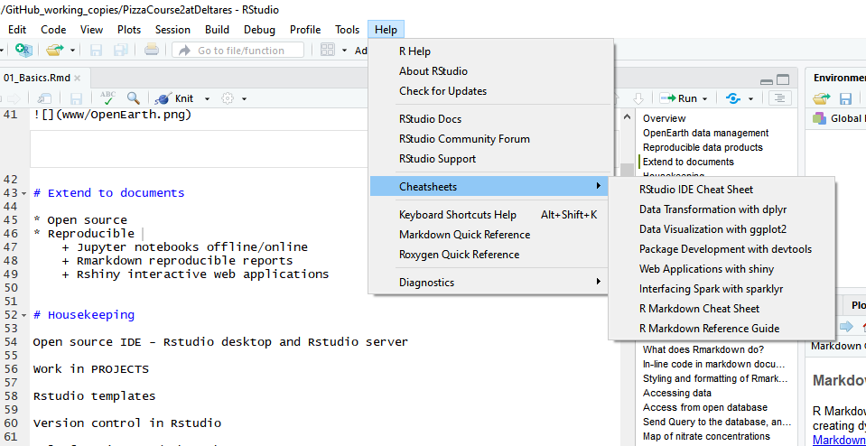

## Rmarkdown

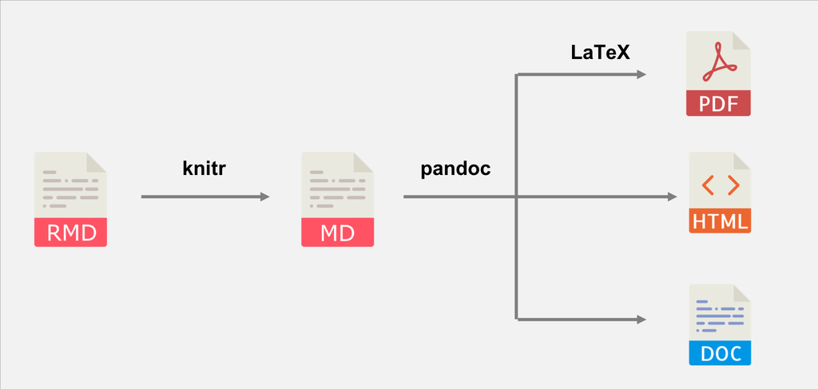

## Knitr

- R package
- Dynamic report generation
- Integration of (evaluated) code into documents

[Home of knitr](https://yihui.org/knitr/)

## pandoc

- Document converter
- “Markup format” converter
- Pandoc markdown as intermediate

[Home of pandoc](https://pandoc.org/)

## Markdown

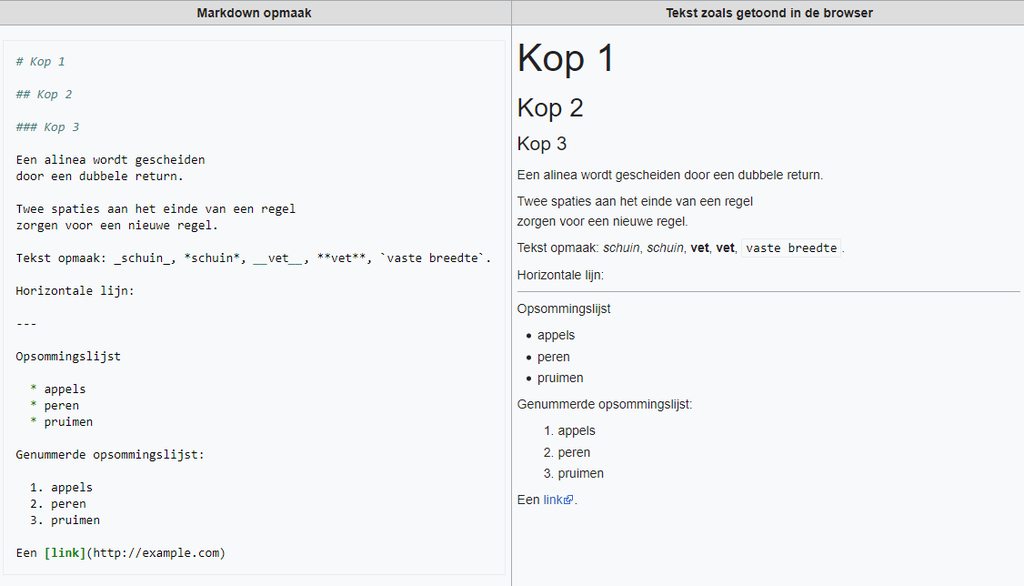

## R markdown

Filetype which combines R code chunks with markdown text (*.Rmd)

R Package using

- knitr
- markdown
- pandoc
- Combines code with markdown for use with Pandoc

[The Definitive Guide](https://bookdown.org/yihui/rmarkdown/)

## Knit to html

Interactive graphics e.g.

- leaflet maps
- plotly objects
- dygraph objects for time series

styling with html or separate css

[more details](https://bookdown.org/yihui/rmarkdown/html-document.html)

## Knit to pdf

Latex needed

- Miktex works well
- TinyTex (R package for easy install of light version for use with Rmarkdown

Latex templates

## Knit to MS-Word

- Not recommended as final product (not reproducible because it can be edited afterwards).

*.doc(x) as style templates

## R markdown files

YAML header

## In-line code in markdown document

Or run inline code to calculate that the average speed = 15.4 .

in Rmarkdown:

Or run inline code to calculate that the average speed = `r_ mean(cars$speed) ` .

## Break

## Bookdown

Builds on Rmarkdown

- Numbering and cross-referencing
- Footnotes
- Literature references using bibtex
- Knit multiple files to one document
  - All .Rmd files in director that do not start with "_"
  - Alt, specify .Rmd files in yaml
  - Use child documents

## Bookdown (2)

- Built-in formats
  - Gitbook
  - Tufte handout and html
- Tools for making your own templates

[home to bookdown](https://bookdown.org/yihui/bookdown/)

## example WFS

[What is WFS en how to?](https://publicwiki.deltares.nl/display/OET/WFS+primer)  
First look what is in the wfs (can also interactively be done in QGIS)

## Connect to WFS

Read WFS layer and plot in leaflet map The data that are used here are pelagic fish data from the MEP-NSW ecological monitoring.

[interactive chart not shown]

Map of pelagic fish haul locations (only first 50 records)